# Smart Agriculture: A Machine Learning Approach to Crop Recommendations in India

## Partial Dependence Plots

```python
# Load the dataset
df_copy = pd.read_csv('https://raw.githubusercontent.com/GertFriborg/Data/refs/heads/main/DATA103/Crop_recommendation.csv')
df_copy.head()
```

|  | N | P | K | temperature | humidity | ph | rainfall | label |
| --- | --- | --- | --- | --- | --- | --- | --- | --- |
| 0 | 90 | 42 | 43 | 20.879744 | 82.002744 | 6.502985 | 202.935536 | rice |
| 1 | 85 | 58 | 41 | 21.770462 | 80.319644 | 7.038096 | 226.655537 | rice |
| 2 | 60 | 55 | 44 | 23.004459 | 82.320763 | 7.840207 | 263.964248 | rice |
| 3 | 74 | 35 | 40 | 26.491096 | 80.158363 | 6.980401 | 242.864034 | rice |
| 4 | 78 | 42 | 42 | 20.130175 | 81.604873 | 7.628473 | 262.717340 | rice |

```python
# Load dataset and define X (features) and y (target)
X_copy = df_copy.drop(['label', 'ph'], axis=1)
y_copy = df_copy['label']
```

```python
# Drop 'ph' from the training and testing sets
X_train_copy, X_test_copy, y_train_copy, y_test_copy = train_test_split(X_copy, y_copy, test_size=0.2, random_state=42)
```

```python
# Obtain a copy of feature names without ph feature
feature_names = X_train_copy.columns.tolist()
```

```python
feature_names
```

```
['N', 'P', 'K', 'temperature', 'humidity', 'rainfall']
```

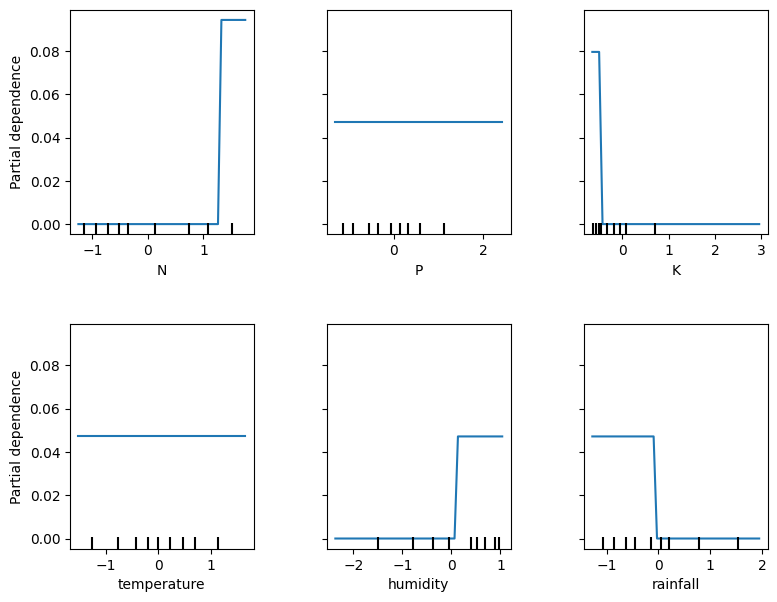

```python
from sklearn.inspection import partial_dependence, PartialDependenceDisplay

# Create the Partial Dependence Plots for Cotton
features = [0, 1, 2, 3, 4, 5]
PartialDependenceDisplay.from_estimator(
    dt,
    X_train_scaled,
    features,
    feature_names=feature_names,
    target=6,  # Cotton
    kind='average',
    grid_resolution=50  # Higher resolution for smoother lines
)

# Adjust the layout for better spacing
plt.gcf().set_size_inches(9, 7)  # Increase figure size
plt.subplots_adjust(hspace=0.4, wspace=0.4)  # Adjust horizontal and vertical spacing
plt.show()
```

**Discussion on PDP Results: Cotton**

For nitrogen, the partial dependence shows a sharp peak around 1, below this threshold, nitrogen has minimal impact on classification probability. An increase in the partial dependence means the likelihood of recommending cotton increases when the threshold for nitrogen has been reached.

As for potassium, there is a sharp decline in the partial dependence at low potassium levels. Beyond this point, the changes in potassium have minimal effect to classification probability. This further implies that the variation in potassium levels don’t influence the likelihood that cotton will be recommended.

In the context of humidity, the partial dependence increases when humidity reaches a specific threshold above 0. Below this point, there is negligible impact to the prediction. When it does reach the threshold, the likelihood of recommending cotton increases.

As for rainfall, lower rainfall is favored, where it has higher likelihood of recommending cotton, and when it reaches a particular threshold, it would decrease, further implying that the model would not recommend cotton. This suggests that the cotton plant needs only moderate rainfall as excessive rainfall would be detrimental to plant growth and health.

Both features for temperature and phosphorus (P) plots show a flat line, indicating that variations in temperature and phosphorus levels have mostly no impact on cotton crop outcome. This finding is aligned with the findings from SHAP, where both features also don’t influence the model’s predictions.

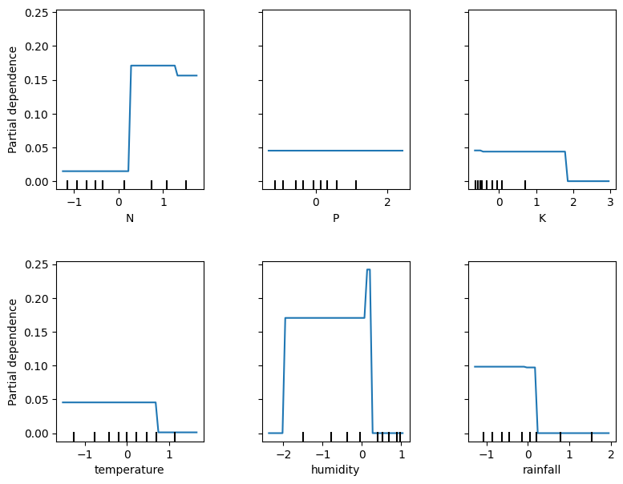

```python
# Create the Partial Dependence Plots for Maize
PartialDependenceDisplay.from_estimator(
    dt,
    X_train_scaled,
    features,
    feature_names=feature_names,
    target=11,  # Maize
    kind='average',
    grid_resolution=50  # Higher resolution for smoother lines
)

# Adjust the layout for better spacing
plt.gcf().set_size_inches(9, 7)  # Increase figure size
plt.subplots_adjust(hspace=0.4, wspace=0.4)  # Adjust horizontal and vertical spacing
plt.show()
```

**Discussion on PDP Results: Maize**

In the partial dependence plot (PDP) for nitrogen, there is a noticeable rise in classification probability as nitrogen levels increase, peaking at around 0.17 before plateauing. After reaching a threshold of 1, the probability dips slightly to approximately 0.15. This indicates that optimal nitrogen levels enhance the likelihood of recommending maize cultivation.

The humidity plot rises sharply to about 0.15 at negative values before plateauing until it peaks between 0.23 and 0.25 at a humidity level of 0. However, it quickly declines back to the lowest point (0.0) as humidity continues to increase beyond this peak. This indicates that moderate humidity is beneficial for maize growth but excessive humidity can be detrimental.

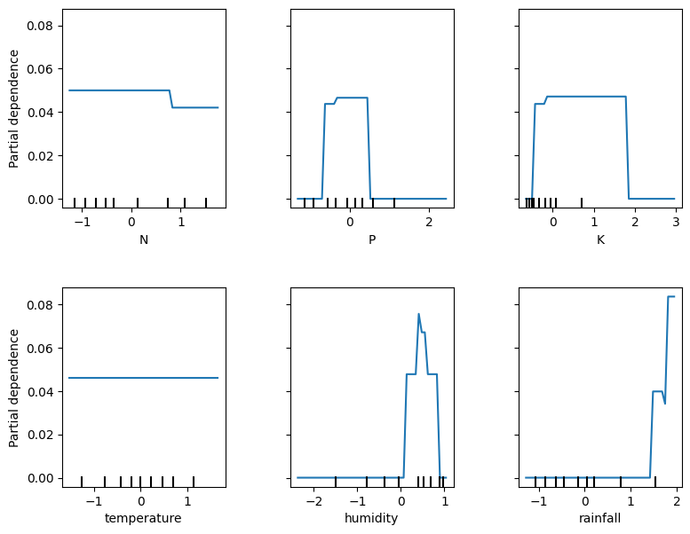

```python
# Create the Partial Dependence Plots for Rice
PartialDependenceDisplay.from_estimator(
    dt,
    X_train_scaled,
    features,
    feature_names=feature_names,
    target=20,  # Rice
    kind='average',
    grid_resolution=50  # Higher resolution for smoother lines
)

# Adjust the layout for better spacing
plt.gcf().set_size_inches(9, 7)  # Increase figure size
plt.subplots_adjust(hspace=0.4, wspace=0.4)  # Adjust horizontal and vertical spacing
plt.show()
```

**Discussion on PDP Results: Rice**

The analysis reveals a sharp increase in classification probability as potassium levels rise, peaking before reaching the 0 mark. After this peak, the probability plateaus before declining sharply around a potassium level of 2. This indicates that while potassium is beneficial up to a certain point, excessive levels can be detrimental to rice health and yield.

# X. Conclusion and Recommendations

**Conclusion**

The comprehensive analysis of crop recommendation models has underscored the significant role of machine learning in addressing the complexities of agricultural data. Out of the 6 implemented machine learning models, the most optimal machine learning classification model for crop prediction given the various environmental conditions is the **Decision Tree (Base Model)** given that it has the best train and test result metrics. One of the strengths of the decision tree is that it is highly interpretable, which made it easy to understand how specific crop recommendations are made. Moreover, another strength of the model includes how these decision trees inherently capture non-linear relationships, further enabling them to model complex interactions between different factors that has worked to the advantage of the study. The utilization of machine learning algorithms in crop recommendation is particularly relevant in the context of India’s diverse agricultural landscape, where crops like rice, maize, and cotton are pivotal to food security and economic stability.

In terms of crop recommendation, the most impactful feature that significantly influence crop predictions given the results is **Humidity**. This feature is crucial for the growth of cotton, rice, and corn as it directly affects transpiration, nutrient uptake, and photosynthesis processes. High humidity levels are essential for rice, a water-loving crop, to maintain adequate moisture for its growth. For cotton and corn, moderate humidity prevents excessive water loss while supporting healthy development, ensuring optimal yields and quality. The explainability AI results for both SHAP and PDP are consistent with how relevant humidity is towards the growth of the selected crops. These results provide more context as to what farmers should be focusing on when managing the growth of their crops.

**Reconnect research objectives with findings**

Ultimately, the study has been able to address the several research objectives that were set. (1) The study was able to develop 6 machine learning models in the context of an agriculture dataset. (2) The study was able to evaluate each model’s performance. The best model of which was the Decision Tree Base model, whereas the worst model to come out is the ridge classifier. (3) In terms of enhancing decision-making for farmers, the study found out the most relevant environmental feature for the crops of rice, maize, and cotton. Based on the results for explainability AI of SHAP and PDP, the most relevant feature is Humidity. (4) The research contributes to sustainable agriculture by utilizing data-driven methods to increasing the productivity of farmers, and optimizing resource use, given that these farmers would now know the relevant environmental features and conditions that are essential to growing their crop.

**Recommendations**

The authors thought of 3 possible recommendations for further studies in the realm of crop recommendation using machine learning classification techniques.

**A. Use of Alternative Machine Learning Models**

Further studies could also look into the different types of ML models. These include the KNN Classification and the SVM Multiclass Classification. Additionally, unsupervised Machine Learning Models can also be explored.

**B. Use of Alternative Datasets**

For further studies, the researchers recommend to utilize datasets that utilizes real-world data, which could be sourced from government institutions or Agricultural authorities to make it more impactful and to put it in the real-life context. Moreover, an alternative dataset covering the Philippines and its context could give interesting insights on particular native crops.

**C. New Approaches to the Project**

Engaging with local agricultural experts during model development could refine feature selection based on practical knowledge and regional practices. This would benefit further studies given that these experts could provide technical knowledge that would contribute to the enhancement of the model and the study.

# XI. References

Ahmad et al., (2018). Spatial Field Survey of Cotton Whitefly and its Pupal Parasitism in Relation to Temperature and Humidity in Southern Pakistan. Pakistan Journal of Zoology. https://www.researchgate.net/publication/325113763_Spatial_Field_Survey_of_Cotton_Whitefly_and_its_Pupal_Parasitism_in_Relation_to_Temperature_and_Humidity_in_Southern_Pakistan

Anand, A. (2024). Bumper harvest forecast for Indian rice as La Niña likely to return in 2024. In A. Agnihotri (Ed.), S&P Global. https://www.spglobal.com/commodityinsights/en/market-insights/latest-news/agriculture/052324-bumper-harvest-forecast-for-indian-rice-as-la-nina-likely-to-return-in-2024

Babu, M., & Reddy, K. R. (2020). Assessment of crop yield prediction using machine learning algorithms. Agricultural Systems, 182, 102873. https://doi.org/10.1016/j.agsy.2020.102873

Bouteska, A., Sharif, T., Bhuiyan, F., & Abedin, M. Z. (2024). Impacts of the changing climate on agricultural productivity and food security: Evidence from Ethiopia. Journal of Cleaner Production, 449, 141793. https://doi.org/10.1016/j.jclepro.2024.141793

Chia, S. & Lim, M. (2022). A critical review on the influence of humidity for plant growth forecasting. Materials Science and Engineering. https://iopscience.iop.org/article/10.1088/1757-899X/1257/1/012001/pdf

Choudhary, A., & Dass, S. (2024). India needs a new maize revolution. The Hindu Business Line. Retrieved from https://www.thehindubusinessline.com/economy/agri-business/india-needs-a-new-maize-revolution/article67974954.ece

Cotecna. (2024). India: Rice market trends and prospects. Retrieved from https://www.cotecna.com/en/media/news/india-rice-market-trends-and-prospects

Decision Trees vs Random Forests: Comparing Predictive Power. (2024). Data Headhunters. https://dataheadhunters.com/academy/decision-trees-vs-random-forests-comparing-predictive-power/

Dobbins, I. (2021). The effect of soil pH on plants. Southland Organics. https://www.southlandorganics.com/blogs/news/the-effect-of-soil-ph-on-plants

Ellis, C. (2022). When to use logistic regression. Crunching the Data. https://crunchingthedata.com/when-to-use-logistic-regression/

Gray, E. (2021). Global Climate Change Impact on Crops Expected Within 10 Years, NASA Study Finds. NASA Global Climate Change. https://climate.nasa.gov/news/3124/global-climate-change-impact-on-crops-expected-within-10-years-nasa-study-finds/

Kingma, D. P., & Ba, J. (2014). Adam: A Method for Stochastic Optimization. arXiv preprint arXiv:1412.6980. https://arxiv.org/abs/1412.6980.

Navlani, A. (2024). Understanding Logistic Regression in Python. Data Camp. https://www.datacamp.com/tutorial/understanding-logistic-regression-python Raafat, A. (2022). Decision Trees And Random Forests, All You Need To Know. Machine Learning Archive. https://mlarchive.com/machine-learning/decision-trees-and-random-forest-all-you-need-to-know/

Rezaei, E. E., Webber, H., Asseng, S., Boote, K., Durand, J. L., Ewert, F., Martre, P., & others. (2023). Climate change impacts on crop yields. Nature Reviews Earth & Environment, 4(12), 831-846. https://doi.org/10.1038/s43017-023-00514-1

Ronnback, K. & Theodoridis, D. (2022). Cotton cultivation under colonial rule in Indiain the nineteenth century from a comparativeperspective. The Economic History Review. https://onlinelibrary.wiley.com/doi/epdf/10.1111/ehr.13094

PJTSAU. (2024). Maize Outlook – April 2024. Retrieved from https://www.pjtsau.edu.in/files/AgriMkt/2024/April/Maize-April-2024.pdf

Prabavathi, R., Subha, P., Bhuvaneswari, M., Prithisha, V., & Roshini, K. (2024). IoT based soil pH detection and crop recommendation system. International Journal of Innovative Science and Research Technology, 9(4), 1-7. https://www.ijisrt.com/assets/upload/files/IJISRT24APR532.pdf Sahu, S., & Sharma, A. (2019). A review on crop yield prediction using machine learning techniques: Current trends and future prospects. Computers and Electronics in Agriculture, 155, 447-458. https://doi.org/10.1016/j.compag.2018.11.034

Saini, S. (2024). For India, is there light at the end of this maize? Deccan Herald. Retrieved from https://www.deccanherald.com/opinion/for-india-is-there-light-at-the-end-of-this-maize-3187433

Saini, D.K., Impa, S.M., McCallister, D. et al. (2023).High day and night temperatures impact on cotton yield and quality—current status and future research direction. J Cotton Res 6, 16 https://doi.org/10.1186/s42397-023-00154-x

Sharma, H. (2024). Kharif rice production to reach record high of 119.93 million tonnes, says agriculture ministry. Indian Express. https://indianexpress.com/article/india/kharif-rice-production-to-reach-record-high-agriculture-ministry-9654600/

Sharma, R., Singh, R., & Kumar, A. (2020). Machine learning applications in agriculture: A review. Agricultural Systems, 178, 102751. https://doi.org/10.1016/j.agsy.2019.102751

Stuerz, S. & Ash, F. (2019). Responses of Rice Growth to Day and Night Temperature and Relative Air Humidity—Dry Matter, Leaf Area, and Partitioning. Plants. https://www.mdpi.com/2223-7747/8/11/521

Tababa, J. (2023). Complex interactions: The interactions between soil nutrients and plant growth. Manila Bulletin. https://www.manilabulletin.com/2023/06/29/complex-interactions-the-interactions-between-soil-nutrients-and-plant-growth/

Walne, C. & Reddy, K. (2022). Temperature Effects on the Shoot and Root Growth, Development, and Biomass Accumulation of Corn (Zea mays L.). Agriculture. https://www.mdpi.com/2077-0472/12/4/443

Yang et al. (2024). Remote Sensing-Based Monitoring of Cotton Growth and Its Response to Meteorological Factors. Agriculture. https://www.mdpi.com/2071-1050/16/10/3992

```python
%%shell
jupyter nbconvert --to html /content/DaSilva_DelaCruz_Friborg_Suaybaguio_DATA103_Final_Project.ipynb
```

[output not shown]

[output not shown]